# Geospatial Risk Predictions

Trevor Kapuvari

10/18/2023

## 0.1 Reading Data from Chicago

```r
policeDistricts <-
  st_read("https://data.cityofchicago.org/api/geospatial/fthy-xz3r?method=export&format=GeoJSON") %>%
  st_transform('ESRI:102271') %>%
  dplyr::select(District = dist_num)
drugArrest <-
  read.socrata("https://data.cityofchicago.org/Public-Safety/Crimes-2017/d62x-nvdr") %>%
    filter(Primary.Type == "NARCOTICS" & Description == "POSS: CANNABIS 30GMS OR LESS" | Description == "POSS: CANNABIS MORE THAN 30GMS") %>%
    mutate(x = gsub("[()]", "", Location)) %>%
    separate(x,into= c("Y","X"), sep=",") %>%
    mutate(X = as.numeric(X),Y = as.numeric(Y)) %>%
    na.omit() %>%
    st_as_sf(coords = c("X", "Y"), crs = 4326, agr = "constant")%>%
    st_transform('ESRI:102271') %>%
    distinct()


chicagoBoundary <-
  st_read("https://data.cityofchicago.org/api/geospatial/ewy2-6yfk?method=export&format=GeoJSON") %>%
  st_transform('ESRI:102271')
```

# 1 Introduction

# 2 Outcome of Interest Points

> How do we analyze point data?

> Are there other geometries useful to represent point locations?

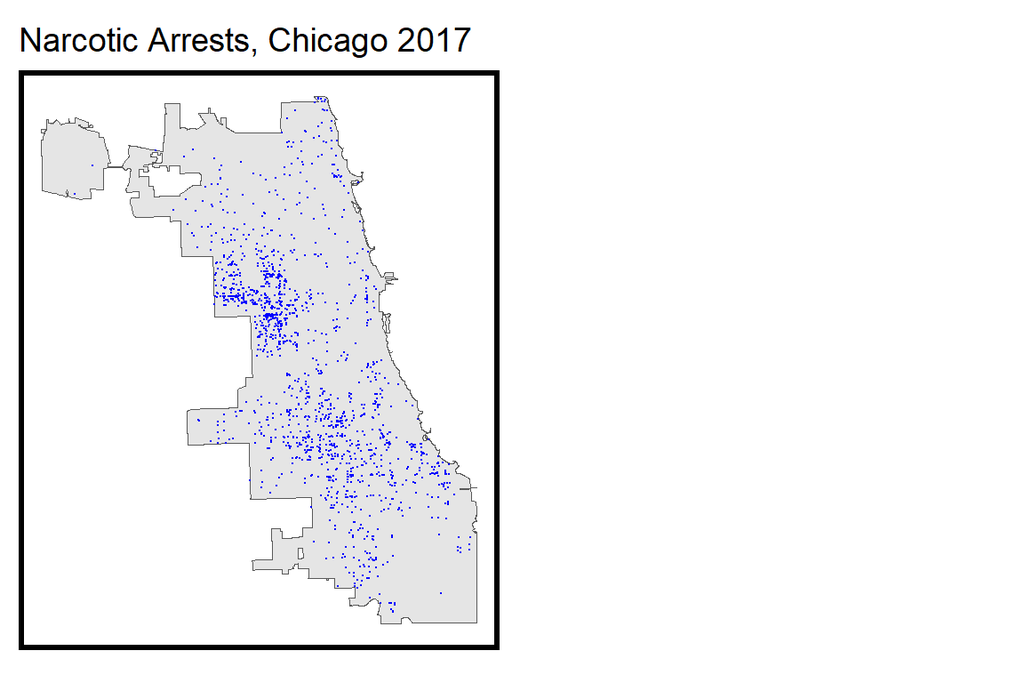

```r
# uses grid.arrange to organize independent plots
grid.arrange(ncol=2,
ggplot() +
  geom_sf(data = chicagoBoundary) +
  geom_sf(data = drugArrest, colour="blue", size=0.1, show.legend = "point") +
  labs(title= "Narcotic Arrests, Chicago 2017") +
  mapTheme(title_size = 14))
```

# 3 Fishnet Grid of Narcotic Arrests

> What is a fishnet grid?

The `{sf}` package offers really easy way to create fishnet grids using the `st_make_grid()` function. The `cellsize` argument allows you to set the size of the grid cells; in this case it is set to `500` meters. You may have to do some research on the spatial layers projection (using `st_crs()` to know what coordinate system you are in) to understand if you are in feet or meters. If you are using Longitude and Latitude, you will need to project the data to a projected coordinate system to get distance measurements.

Examine the fishnet - the unique ID is crucial to building a data set!

```r
## using {sf} to create the grid
## Note the `.[chicagoBoundary] %>% ` line. This is needed to clip the grid to our data
fishnet <-
  st_make_grid(chicagoBoundary,
               cellsize = 500,
               square = TRUE) %>%
  .[chicagoBoundary] %>%            # fast way to select intersecting polygons
  st_sf() %>%
  mutate(uniqueID = 1:n())
```

### 3.0.1 Aggregate points to the fishnet

> How can we aggregate points into a fishnet grid?

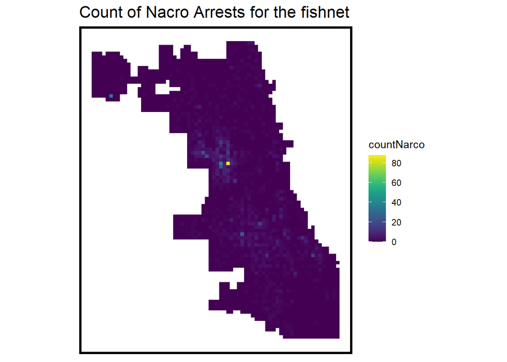

```r
## add a value of 1 to each crime, sum them with aggregate
crime_net <-
  dplyr::select(drugArrest) %>%
  mutate(countNarco = 1) %>%
  aggregate(., fishnet, sum) %>%
  mutate(countNarco = replace_na(countNarco, 0),
         uniqueID = 1:n(),
         cvID = sample(round(nrow(fishnet) / 24),
                       size=nrow(fishnet), replace = TRUE))

ggplot() +
  geom_sf(data = crime_net, aes(fill = countNarco), color = NA) +
  scale_fill_viridis() +
  labs(title = "Count of Nacro Arrests for the fishnet") +
  mapTheme()
```

# 4 A small multiple map of your risk factors in the fishnet (counts, distance and/or other feature engineering approaches).

> What features would be helpful in predicting the location of narcotics? care in the community, what indicator can show care and upbringing in community? murals? prove that murals can reate a sense of community, beautify urban spaces, express historical and cultural identity, raise awareness about social issues, and inspire creativity and wonder. Murals may decrease narcotic arrests and broken window policing.

> What might these features be problematic?

> hint: for all the reasons we learned in class

```r
## only pulling a single variable for our model to keep it simple
## using Socrata again
registeredMurals <-
  read.socrata("https://data.cityofchicago.org/Historic-Preservation/Mural-Registry/we8h-apcf") %>%
    dplyr::select(Y = latitude, X = longitude) %>%
    na.omit() %>%
    st_as_sf(coords = c("X", "Y"), crs = 4326, agr = "constant") %>%
    st_transform(st_crs(fishnet)) %>%
    mutate(Legend = "Registered_Murals") %>%
    mutate(uniqueID = 1:n(),) %>%
    filter(uniqueID != 439) %>%
    filter(uniqueID != 440) %>%
    filter(uniqueID != 441) %>%
    filter(uniqueID != 442) %>%
    filter(uniqueID != 443) %>%
    group_by(Legend)

registeredMurals <- registeredMurals %>%
  dplyr::select(geometry, Legend)


parks <-
  st_read("https://github.com/TrevorKap/MUSA5000/raw/main/lowkeyPPA/Geospatial/Parks%20-%20Chicago%20Park%20District%20Facilities%20(current).geojson") %>%
  st_transform(st_crs(fishnet))
parks <- parks %>%
  group_by(park) %>%
  rename(Legend = park) %>%
  summarise()

parks$Legend = "park"

## Neighborhoods to use in LOOCV in a bit

neighborhoods <-
  st_read("https://raw.githubusercontent.com/blackmad/neighborhoods/master/chicago.geojson") %>%
  st_transform(st_crs(fishnet))
abandoned_buildings <-
  read.socrata("https://data.cityofchicago.org/Service-Requests/311-Service-Requests-Vacant-and-Abandoned-Building/7nii-7srd") %>%
  mutate(year = substr(date_service_request_was_received,1,4)) %>%  filter(year == "2017") %>%
  dplyr::select(Y = latitude, X = longitude) %>%
  na.omit() %>%
  st_as_sf(coords = c("X", "Y"), crs = 4326, agr = "constant") %>%
  st_transform(st_crs(fishnet)) %>%
  mutate(Legend = "Abandoned_Buildings")

tracts17 <-
  get_acs(geography = "tract", variables = c("B01001_001E","B01001A_001E"),
          year = 2017, state=17, county=031, geometry=T) %>%
  st_transform('ESRI:102271')  %>%
  dplyr::select(variable, estimate, GEOID) %>%
  spread(variable, estimate) %>%
  rename(TotalPop = B01001_001,
         NumberWhites = B01001A_001) %>%
  mutate(percentWhite = NumberWhites / TotalPop,
         raceContext = ifelse(percentWhite > .5, "Majority_White", "Majority_Non_White"))
vars_net <-
  rbind(registeredMurals, parks, abandoned_buildings) %>%
  st_join(fishnet, join=st_within) %>%
  st_drop_geometry() %>%
  group_by(uniqueID, Legend) %>%
  summarize(count = n()) %>%
  left_join(fishnet, ., by = "uniqueID") %>%
  spread(Legend, count, fill=0) %>%
  dplyr::select(-`<NA>`) %>%
  ungroup()
```

## 4.1 Nearest Neighbor & Count

> added count and nearest neighbor

> Review: what is NN and what does `k` represent in this function?

```r
# convenience to reduce length of function names.
st_c    <- st_coordinates
st_coid <- st_centroid

## create NN from abandoned cars
vars_net <- vars_net %>%
    mutate(Registered_Murals.nn = nn_function(st_c(st_coid(vars_net)),
                                           st_c(registeredMurals),
                                           k = 3))
vars_net <- vars_net %>%
    mutate(abandoned_buildings.nn = nn_function(st_c(st_coid(vars_net)),
                                           st_c(registeredMurals),
                                           k = 3))
```

> What changes if we make `k` a different number?

```r
## Visualize the NN feature
vars_net.long.nn <-
  dplyr::select(vars_net, ends_with(".nn")) %>%
    gather(Variable, value, -geometry)
```

```r
## important to drop the geometry from joining features
final_net <-
  left_join(crime_net, st_drop_geometry(vars_net), by="uniqueID")
```

Using spatial joins to join *centroids* of fishnets to polygon for neighborhoods and districts.

> What issues arise when we try to join polygons to polygons in space?

```r
final_net <-
  st_centroid(final_net) %>%
    st_join(dplyr::select(neighborhoods, name), by = "uniqueID") %>%
    st_join(dplyr::select(policeDistricts, District), by = "uniqueID") %>%
      st_drop_geometry() %>%
      left_join(dplyr::select(final_net, geometry, uniqueID)) %>%
      st_sf() %>%
  na.omit()
```

```r
# for live demo
# mapview::mapview(final_net, zcol = "District")
```

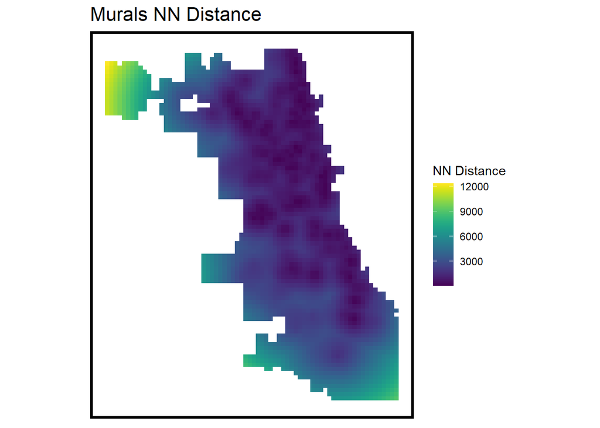

```r
ggplot() +
      geom_sf(data = vars_net.long.nn, aes(fill=value), colour=NA) +
      scale_fill_viridis(name="NN Distance") +
      labs(title="Murals NN Distance") +
      mapTheme()
```

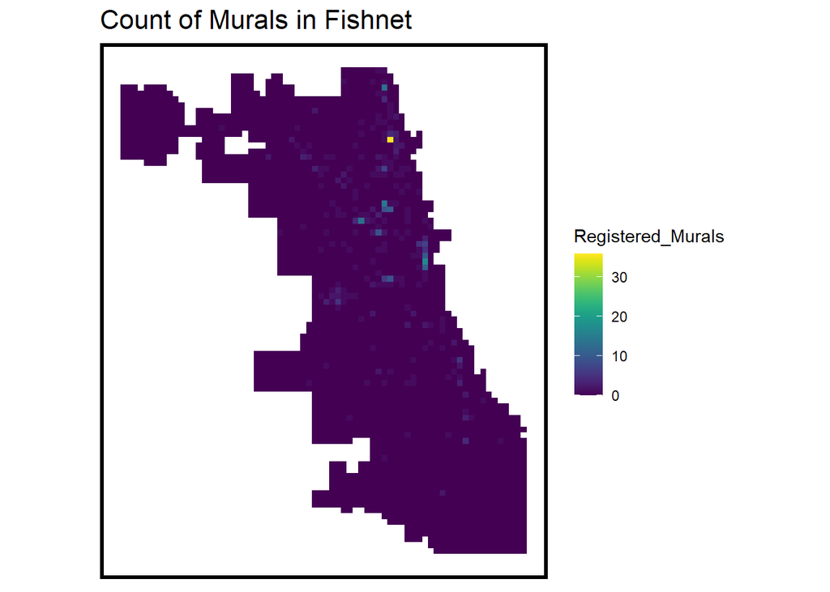

```r
ggplot() +
  geom_sf(data = vars_net, aes(fill=Registered_Murals), colour=NA) +
  scale_fill_viridis() +
  labs(title = "Count of Murals in Fishnet") +
  mapTheme()
```

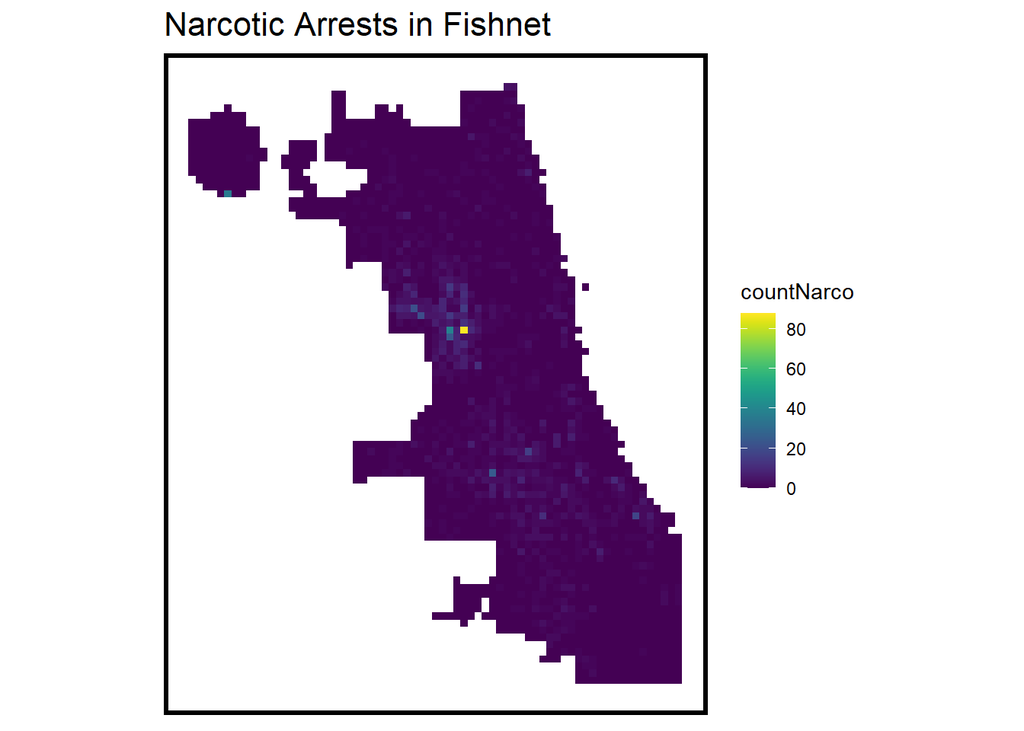

```r
ggplot() +
      geom_sf(data = final_net, aes(fill=countNarco), colour=NA) +
      scale_fill_viridis() +
      labs(title="Narcotic Arrests in Fishnet") +
      mapTheme()
```

# 5 Local Moran’s I

using {spdep} package to to build neighborhood weights and list to calculate local Moran’s I.

Note that the code here is *different* than in the book - it has been updated to keep up with changes in packages.

> What is the difference between local and global Moran’s I?

A little in depth version of the chunk below can be found:

Mendez C. (2020). Spatial autocorrelation analysis in R. R Studio/RPubs. Available at https://rpubs.com/quarcs-lab/spatial-autocorrelation

```r
## generates warnings from PROJ issues
## {spdep} to make polygon to neighborhoods...
final_net.nb <- poly2nb(as_Spatial(final_net), queen=TRUE)
## ... and neighborhoods to list of weigths
final_net.weights <- nb2listw(final_net.nb, style="W", zero.policy=TRUE)

# print(final_net.weights, zero.policy=TRUE)
```

```r
## see ?localmoran
local_morans <- localmoran(final_net$Registered_Murals, final_net.weights, zero.policy=TRUE) %>%
  as.data.frame()

# join local Moran's I results to fishnet
final_net.localMorans <-
  cbind(local_morans, as.data.frame(final_net)) %>%
  st_sf() %>%
  dplyr::select(Registered_Murals_Count = Registered_Murals,
                Local_Morans_I = Ii,
                P_Value = `Pr(z != E(Ii))`) %>%
  mutate(Significant_Hotspots = ifelse(P_Value <= 0.001, 1, 0)) %>%
  gather(Variable, Value, -geometry)
```

## 5.1 Plotting local Moran’s I results

This is a complex code chunk - it’s a loop which builds ggplots of local Moran’s for each of your `vars`

[figure not shown]

```r
## This is just for plotting
vars <- unique(final_net.localMorans$Variable)
varList <- list()

for(i in vars){
  varList[[i]] <-
    ggplot() +
      geom_sf(data = filter(final_net.localMorans, Variable == i),
              aes(fill = Value), colour=NA) +
      scale_fill_viridis(name="") +
      labs(title=i) +
      mapTheme(title_size = 14) + theme(legend.position="bottom")}

do.call(grid.arrange,c(varList, ncol = 4, top = "Local Morans I statistics, Narcotics"))
```

```r
# generates warning from NN
final_net <- final_net %>%
  mutate(Mural.isSig =
           ifelse(local_morans[,5] <= 0.001, 1, 0)) %>%
  mutate(Mural.isSig.dist =
           nn_function(st_c(st_coid(final_net)),
                       st_c(st_coid(filter(final_net,
                                           Mural.isSig == 1))), k = 1))

## What does k = 1 represent?
```

# 6 Multiple Scatterplot with Correlation

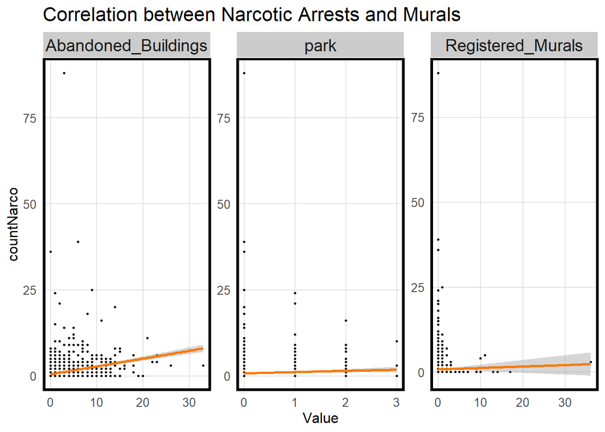

```r
final_net_nongeom <- final_net %>% st_drop_geometry()

final_net_nongeom %>%
  dplyr::select(countNarco, Registered_Murals, park, Abandoned_Buildings) %>%
  gather(Variable, Value, -countNarco) %>%
  ggplot(aes(Value, countNarco)) +
     geom_point(size = .5) + geom_smooth(method = "lm", colour = "#FA7800") +
     facet_wrap(~Variable, nrow = 1, scales = "free") +
     labs(title = "Correlation between Narcotic Arrests and Murals") +
     plotTheme()
```

# 7 Histogram of Dependent Varaible (Narcotic Arrests)

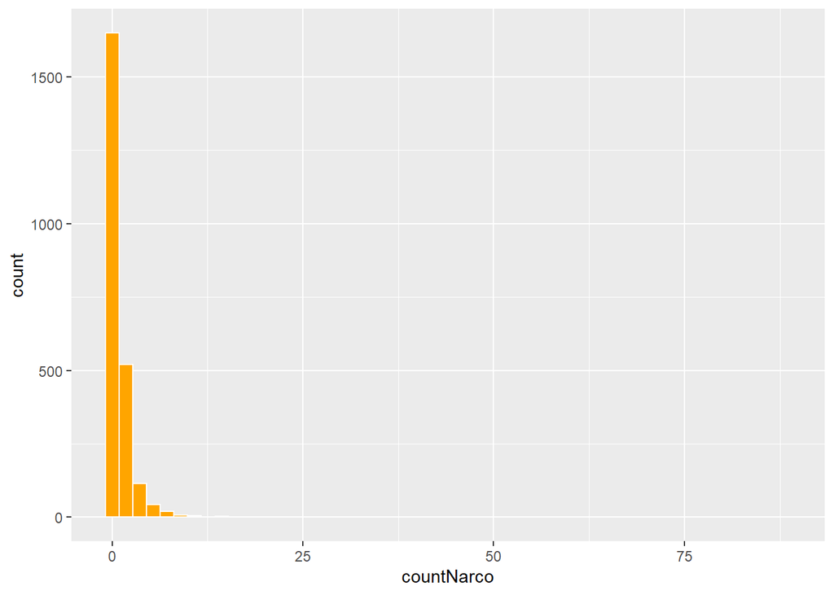

```r
  ggplot(final_net, aes(x=countNarco)) +
  geom_histogram(color='white',fill="orange", bins=50)+
  scale_x_continuous()+
  scale_y_continuous()
```